# Week 1 Exercises

2020-07-13

# 1 The basics

## 1.1 Install and set up R and RStudio

### Install R

First, install R at this link: https://cran.r-project.org/mirrors.html. Choose a mirror approximately close to you geographically, and then choose the option corresponding to your operating system:

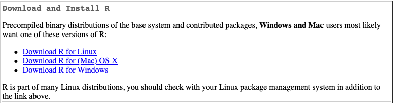

Follow all the operating system-specific instructions.

Congratulations! 🥳 You have R installed! That means you could write an R script and run it. But let’s make things a lot easier by downloading RStudio, which will keep us organized and supply us with lots of shortcuts.

### Install R Studio

You can download RStudio at this link: https://rstudio.com/products/rstudio/download/. Choose the RStudio Desktop free version on the left:

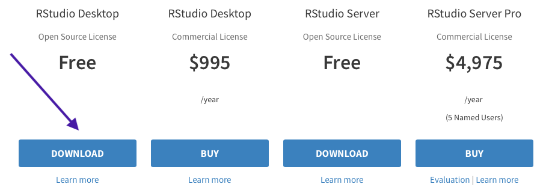

And then the blue download button near the top should match your operating system. If not, you can choose from the list below it.

[figure not shown]

Again follow the instructions for download. Now open up RStudio. It should automatically be connected with R!

### Personalize R Studio

There’s a lot you can do to personalize RStudio. Feel free to explore all the options and do what you want with it.[^1] You can do a lot of personalization through the “Global Options” menu under “Tools”. Here’s what it looks like on Windows:

[figure not shown]

🛑 One change that I will **request** that you make is to change what RStudio does when you restart R. You want your settings to look like this:

[figure not shown]

(You will have to restart RStudio.)

The reason I want you to set things up this way is because it’s *really* easy to make mistakes if you let R remember the data and packages you had loaded the last time you used it.

## 1.2 Install and load packages

### Install the `tidyverse` package

Open up RStudio. In the **console**, type in `install.packages("tidyverse")` and press enter. Then wait a while. Voilà! You have just installed a lot of super useful packages.

You ran that code in the **console** because it’s not something you’ll need to run again or look back at. When you are *loading* a package, you’ll want to do that from a **script**. You’ll want a record of the fact that you loaded the package so that if you or someone else wants to rerun the code, they’ll have the appropriate packages.

If you’re trying to run code that requires a package you haven’t installed, either RStudio will suggest they do so (because RStudio is magical 🧙), or you’ll get an error when you run `library(package_name)`. In fact, here’s what happens when you try to load that package (which I haven’t installed because it doesn’t exist!)

```r
library(package_name)
```

[output not shown]

### Load the `tidyverse` package

To open a new R **script**, choose “File” -> “New File” -> “R Script”, or simply click on the button with a green plus sign at the upper-left corner of the window. This is a blank document that you can write code in and save to come back to.

In that document, write:

```r
# load packages
library(tidyverse)
```

The first line is a comment, which won’t run when you run the script. Comments in R start with `#` and can include whatever they want after that. To comment out multiple lines, simply preface each one with `#`. (Highlighting them all and using `Cmd`/`Ctrl` + `Shift` + `c` is faster!)

If you highlight both lines, or just put your cursor on the end of the second, and then press `Cmd`/`Ctrl` + `Enter`, the code will run. You should see some text show up in the **console**.

```r
# load packages
library(tidyverse)
```

[output not shown]

The first section is telling you which packages are actually being loaded with the “mega-package” `tidyverse`, and the second section is telling you that there are some functions loaded, specifically from the `dplyr` package, that have the same names as those in the `stats` package. The `stats` package is on that automatically is loaded with R, so you’ll always have these conflicts.

In this class, we’ll be using the `dplyr` versions of those functions, so this isn’t a problem. In general, if you want to be specific about which package a function comes from, you can write, e.g., `stats::filter(x)`, so that R knows to use the version of the `filter()` function from the `stats` package.[^2]

### Refresh R and load another package

Now let’s see what happens when we restart R. There are two ways to do this:

1. Literally quit RStudio, and open it back up again.
2. Go to `Session -> Restart R` in the menu bar. There’s also a keyboard shortcut you can memorize.[^3]

Now, open a new file, and type in and run this code:

```r
ggplot(mpg, aes(displ, hwy, colour = class)) +
  geom_point() +
  geom_smooth(se = FALSE, method = lm)
```

You should get this error:

```
#>  Error in ggplot(mpg, aes(displ, hwy, colour = class)): could not find function "ggplot"
```

If you didn’t, you didn’t correctly restart R! 🤦 Try again.

Now add the necessary `library()` call and run the whole thing again:

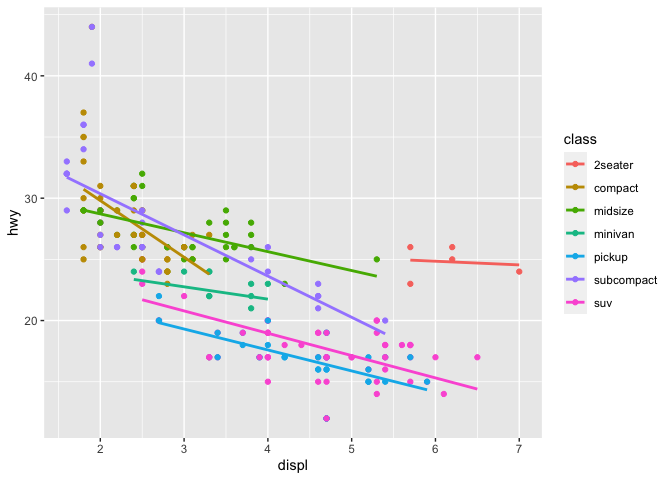

```r
library(ggplot2)
ggplot(mpg, aes(displ, hwy, colour = class)) +
  geom_point() +
  geom_smooth(se = FALSE, method = lm, formula = "y ~ x")
```

You should see this figure pop up in the Plots window!

You can quit RStudio and you don’t have to save this file. We’ll be back to figures like that next week! 📊

## 1.3 Organize your files

Click [here](http://intro-to-r-2020.louisahsmith.com/exercises/01-week.zip) to download this week’s files. You’ll have to unzip it to access the files inside. This is a little annoying if you are on Windows, but you can follow these instructions:

### Unzip a folder in Windows

1. Save the zip file to Downloads. You should see something like this:

[figure not shown]

2. Go up to `Extract -> Compressed Folder Tools -> Extract All`, like this:

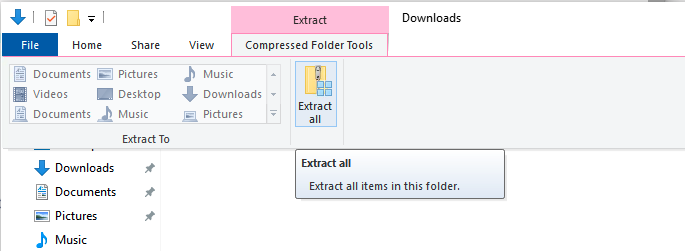

3. Just leave the default folder for extraction. We’ll move it later.

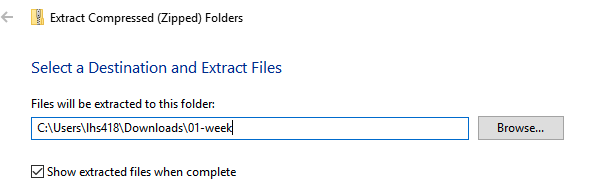

4. Now you’ll see that you’re in the `Downloads/01-week/` folder, in which there’s *another* folder called `01-week`. We want this one. You can ignore the `_MACOSX` one (that’s just there because I made it on a Mac). Move this `01-week` folder to wherever you’re keeping files for this class, e.g., in a folder called `R-course` as in the slides. (Here I’m moving it to a folder called `R` – don’t do this, name it something better!)

[figure not shown]

5. Then, back in your downloads folder, you can delete both folders called `01-week`, because you’ve moved out the stuff you need.

### Unzip a folder on a Mac

1. Go to `Downloads`, or wherever you have files set to download. You’ll see something like this:

[figure not shown]

2. Double click to unzip. You’ll now have the unzipped folder as well. Move that one to wherever you’re keeping files for this class, e.g., in a folder called `R-course` as in the slides. You can delete `01-week.zip`!

[figure not shown]

### Open up an R project

Double-clicking on it *should* open up RStudio. If not, follow these instructions:

#### Open up an R project in Windows

Right-click on the file, then choose `Open with -> Choose another app`. Make sure to `Choose another app` even if RStudio shows up in the `Open with` menu, because you want to change the settings for all `.Rproj` files. Find RStudio and change the settings like this:

[figure not shown]

### Folder structure

Check out your files in the `Files` viewpane (one of the tabs by `Plots`). You should see all the materials for this week! They include:

- `01-week.Rproj`: We’ve covered what this does
- `01-exercise.html`: This is essentially what you see on this webpage, but you can open it up in your browser if you don’t have an internet connection
- `01-exercise.Rmd`: This is the R Markdown file I wrote to generate the webpage, if you want to see the code behind it. You can open it up and click `Knit` at the top of the RStudio window if you want to generate it yourself (you might need to install some packages). Learn more about R Markdown [here](https://rmarkdown.rstudio.com).
- `01-todo.R`: This is the R script you’ll be working with in the next session!

Also check to make sure that you’re in the correct working directory. You can find that at the top of your console pane. It should look something like this:[^4]

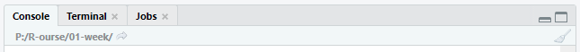

If not, you didn’t open RStudio via the `01-week.Rproj` file. 🤦 Close RStudio and try again!

## 1.4 Run some R code!

Work through the code in `01-todo.R`. You should run the code line-by-line, from a fresh R session (restart if you need to), paying attention to what happens in each of your RStudio windows as you do.

Then answer these questions (also included at the end of the script):

1. Extract `645` from `vals` using square brackets.
2. Extract `"rhino"` from `chars` using square brackets.
3. You saw how to extract the second row of `mat`. Figure out how to extract the second column.
4. Extract `183` from `mat` using square brackets.
5. Figure out how to get the following errors: `incorrect number of dimensions` `subscript out of bounds`

Save your `01-todo.R` script so you can come back to it later! We’ll go over any questions you have during lab. See you then! 👋

[^1]: For example, I use the Fira Code font. Instructions to install can be found [here](https://github.com/tonsky/FiraCode/wiki/RStudio-instructions). Beyond the themes that come pre-installed with RStudio, there are a variety of others available with the `rsthemes` package [here](https://github.com/gadenbuie/rsthemes). You can also make your own theme! There’s more information in [this article](https://support.rstudio.com/hc/en-us/articles/115011846747-Using-RStudio-Themes).
[^2]: See also the [`conflicted` package](https://conflicted.r-lib.org) if this turns out to be a problem often.
[^3]: You can see all the other keyboard shortcuts, or change them, by going to `Tools -> Keyboard Shortcuts Help` or `Modify Keyboard Shortcuts`.
[^4]: My “c” key wasn’t working when I named the “R-course” folder!